# 131 Final Project

# **Missing Values**

I’m going to start by reducing my data set by discarding missing values and narrowing down the variables I am most interested in. This initial step will help ensure the quality and reliability of the data I use for modeling. By removing rows with missing values, I can prevent potential biases and inaccuracies that could arise from incomplete data. Focusing on the most relevant variables will streamline the data set, making it easier to interpret. This targeted approach will improve the efficiency and performance of machine learning models.

```r
library(tidyverse)
```

```r
library(ggplot2)
library(dplyr)
library(DataExplorer) # For automated EDA
library(tidymodels)
library(kknn)
library(yardstick)
library(parsnip)
library(tune)
library(themis)
library(ranger)
library(recipes)

set.seed(123)

setwd("/Users/masondelan/Desktop/131finalproject/")

data <- read.csv("/Users/masondelan/Desktop/131finalproject/merged_data.csv")

str(data)
```

```
## 'data.frame':    26174269 obs. of  29 variables:
##  $ X                  : int  0 1 2 3 4 5 6 7 8 9 ...
##  $ title              : chr  "Chantaje (feat. Maluma)" "Vente Pa' Ca (feat. Maluma)" "Reggaetón Lento (Bailemos)" "Safari" ...
##  $ rank               : int  1 2 3 4 5 6 7 8 9 10 ...
##  $ date               : chr  "2017-01-01" "2017-01-01" "2017-01-01" "2017-01-01" ...
##  $ artist             : chr  "Shakira" "Ricky Martin" "CNCO" "J Balvin, Pharrell Williams, BIA, Sky" ...
##  $ url                : chr  "https://open.spotify.com/track/6mICuAdrwEjh6Y6lroV2Kg" "https://open.spotify.com/track/7DM4BPaS7uofFul3ywMe46" "https://open.spotify.com/track/3AEZUABDXNtecAOSC1qTfo" "https://open.spotify.com/track/6rQSrBHf7HlZjtcMZ4S4bO" ...
##  $ region             : chr  "Argentina" "Argentina" "Argentina" "Argentina" ...
##  $ chart              : chr  "top200" "top200" "top200" "top200" ...
##  $ trend              : chr  "SAME_POSITION" "MOVE_UP" "MOVE_DOWN" "SAME_POSITION" ...
##  $ streams            : num  253019 223988 210943 173865 153956 ...
##  $ track_id           : chr  "6mICuAdrwEjh6Y6lroV2Kg" "7DM4BPaS7uofFul3ywMe46" "3AEZUABDXNtecAOSC1qTfo" "6rQSrBHf7HlZjtcMZ4S4bO" ...
##  $ album              : chr  "El Dorado" "Vente Pa' Ca (feat. Maluma)" "Primera Cita" "Energía" ...
##  $ popularity         : num  78 72 73 0 0 0 56 74 59 0 ...
##  $ duration_ms        : num  195840 259195 222560 205600 234320 ...
##  $ explicit           : chr  "False" "False" "False" "False" ...
##  $ release_date       : chr  "2017-05-26" "2016-09-22" "2016-08-26" "2016-06-24" ...
##  $ available_markets  : chr  "['AR', 'AU', 'AT', 'BE', 'BO', 'BR', 'BG', 'CA', 'CL', 'CO', 'CR', 'CY', 'CZ', 'DK', 'DO', 'DE', 'EC', 'EE', 'S"| __truncated__ "['AR', 'AU', 'AT', 'BE', 'BO', 'BR', 'BG', 'CA', 'CL', 'CO', 'CR', 'CY', 'CZ', 'DK', 'DO', 'DE', 'EC', 'EE', 'S"| __truncated__ "['AR', 'A…
##  $ af_danceability    : num  0.852 0.663 0.761 0.508 0.899 0.776 0.588 0.832 0.736 0.721 ...
##  $ af_energy          : num  0.773 0.92 0.838 0.687 0.626 0.669 0.682 0.772 0.964 0.687 ...
##  $ af_key             : num  8 11 4 0 6 11 11 10 0 1 ...
##  $ af_loudness        : num  -2.92 -4.07 -3.07 -4.36 -4.23 ...
##  $ af_mode            : num  0 0 0 1 0 1 0 1 1 1 ...
##  $ af_speechiness     : num  0.0776 0.226 0.0502 0.326 0.292 0.0638 0.173 0.1 0.129 0.0782 ...
##  $ af_acousticness    : num  0.187 0.00431 0.4 0.551 0.076 0.142 0.0851 0.0559 0.198 0.0998 ...
##  $ af_instrumentalness: num  3.05e-05 1.69e-05 0.00 3.41e-06 0.00 0.00 2.69e-05 4.86e-04 2.32e-06 0.00 ...
##  $ af_liveness        : num  0.159 0.101 0.176 0.126 0.0631 0.219 0.084 0.44 0.336 0.0679 ...
##  $ af_valence         : num  0.907 0.533 0.71 0.555 0.873 0.661 0.937 0.704 0.953 0.825 ...
##  $ af_tempo           : num  102 99.9 94 180 88 ...
##  $ af_time_signature  : num  4 4 4 4 4 4 4 4 4 4 ...
```

It seems like we have too much data for my laptop to handle, I am checking for missing values and removing rows with missing values. I believe that this could affect the data and skew my results, however, I am willing to make this compromise for compilation purposes. Below I am cleaning up the data and printing my data to ensure what I want removed from the data set is gone.

```r
# check for missing values
sum(is.na(data))
```

```
## [1] 10111822
```

```r
missing_values <- colSums(is.na(data))
print(missing_values)
```

```
##                   X               title                rank                date
##                   0                   0                   0                   0
##              artist                 url              region               chart
##                   0                   0                   0                   0
##               trend             streams            track_id               album
##                   0             5852308                   0                   0
##          popularity         duration_ms            explicit        release_date
##              304251              304251                   0                   0
##   available_markets     af_danceability           af_energy              af_key
##                   0              304251              304251              304251
##         af_loudness             af_mode      af_speechiness     af_acousticness
##              304251              304251              304251              304251
## af_instrumentalness         af_liveness          af_valence            af_tempo
##              304251              304251              304251              304251
##   af_time_signature
##              304251
```

```r
# removing rows with any missing values
cleaned_spotify_data <- data %>% drop_na()

# ensuring that missing values have been removed
cleaned_missing_values <-colSums(is.na(cleaned_spotify_data))
print(cleaned_missing_values)
```

```
##                   X               title                rank                date
##                   0                   0                   0                   0
##              artist                 url              region               chart
##                   0                   0                   0                   0
##               trend             streams            track_id               album
##                   0                   0                   0                   0
##          popularity         duration_ms            explicit        release_date
##                   0                   0                   0                   0
##   available_markets     af_danceability           af_energy              af_key
##                   0                   0                   0                   0
##         af_loudness             af_mode      af_speechiness     af_acousticness
##                   0                   0                   0                   0
## af_instrumentalness         af_liveness          af_valence            af_tempo
##                   0                   0                   0                   0
##   af_time_signature
##                   0
```

Here we are reducing the data set size, as we have over 20 million observations. A popularity threshold of greater than 50 has been used as the baseline, excluding observations with a score under 50. I am also limiting my data to about 10,000 observations. This targeted reduction simplifies the data set and focuses analysis on the most relevant and impactful subset of data, ensuring meaningful results aligned with the project’s objectives.

```r
reduced_data <- cleaned_spotify_data %>% sample_frac(0.2) %>% select(title, artist, popularity, af_danceability, af_loudness, af_acousticness, af_energy) %>% filter(popularity > 50) %>%  sample_n(10000)

# checking structure of our reduced data set
str(reduced_data)
```

```
## 'data.frame':    10000 obs. of  7 variables:
##  $ title          : chr  "Rockabye (feat. Sean Paul & Anne-Marie)" "No Limit" "Eastside (with Halsey & Khalid)" "Photograph" ...
##  $ artist         : chr  "Clean Bandit" "G-Eazy, A$AP Rocky, Cardi B" "benny blanco" "Ed Sheeran" ...
##  $ popularity     : num  74 69 75 65 74 83 71 84 80 65 ...
##  $ af_danceability: num  0.72 0.838 0.56 0.614 0.749 0.585 0.716 0.649 0.73 0.789 ...
##  $ af_loudness    : num  -4.07 -3.79 -7.65 -10.48 -5.06 ...
##  $ af_acousticness: num  0.406 0.0117 0.555 0.607 0.0193 0.124 0.462 0.0863 0.132 0.256 ...
##  $ af_energy      : num  0.763 0.771 0.68 0.379 0.794 0.52 0.823 0.716 0.701 0.633 ...
```

I decided to keep a few variables that I am most interested in, which include: artist, title, popularity, danceability, loudness, acousticness, and energy. All of which I believe will give me the most meaningful information about how/why a song is charting high on spotify.

# **EDA**

```r
head(reduced_data)
```

|  | title | artist | popularity | af_danceability | af_loudness | af_acousticness | af_energy |
| --- | --- | --- | --- | --- | --- | --- | --- |
| 1 | Rockabye (feat. Sean Paul & Anne-Marie) | Clean Bandit | 74 | 0.720 | -4.068 | 0.4060 | 0.763 |
| 2 | No Limit | G-Eazy, A$AP Rocky, Cardi B | 69 | 0.838 | -3.791 | 0.0117 | 0.771 |
| 3 | Eastside (with Halsey & Khalid) | benny blanco | 75 | 0.560 | -7.648 | 0.5550 | 0.680 |
| 4 | Photograph | Ed Sheeran | 65 | 0.614 | -10.480 | 0.6070 | 0.379 |
| 5 | Venom - Music From The Motion Picture | Eminem | 74 | 0.749 | -5.063 | 0.0193 | 0.794 |
| 6 | rockstar (feat. 21 Savage) | Post Malone | 83 | 0.585 | -6.136 | 0.1240 | 0.520 |

```r
summary(reduced_data)
```

```
##     title              artist            popularity    af_danceability
##  Length:10000       Length:10000       Min.   :51.00   Min.   :0.2180
##  Class :character   Class :character   1st Qu.:62.00   1st Qu.:0.6100
##  Mode  :character   Mode  :character   Median :71.00   Median :0.7050
##                                        Mean   :70.57   Mean   :0.6877
##                                        3rd Qu.:78.00   3rd Qu.:0.7850
##                                        Max.   :90.00   Max.   :0.9800
##   af_loudness      af_acousticness       af_energy
##  Min.   :-22.507   Min.   :0.0000255   Min.   :0.0316
##  1st Qu.: -7.206   1st Qu.:0.0589000   1st Qu.:0.5380
##  Median : -5.652   Median :0.1770000   Median :0.6620
##  Mean   : -5.985   Mean   :0.2569060   Mean   :0.6421
##  3rd Qu.: -4.374   3rd Qu.:0.3900000   3rd Qu.:0.7650
##  Max.   :  0.175   Max.   :0.9940000   Max.   :0.9890
```

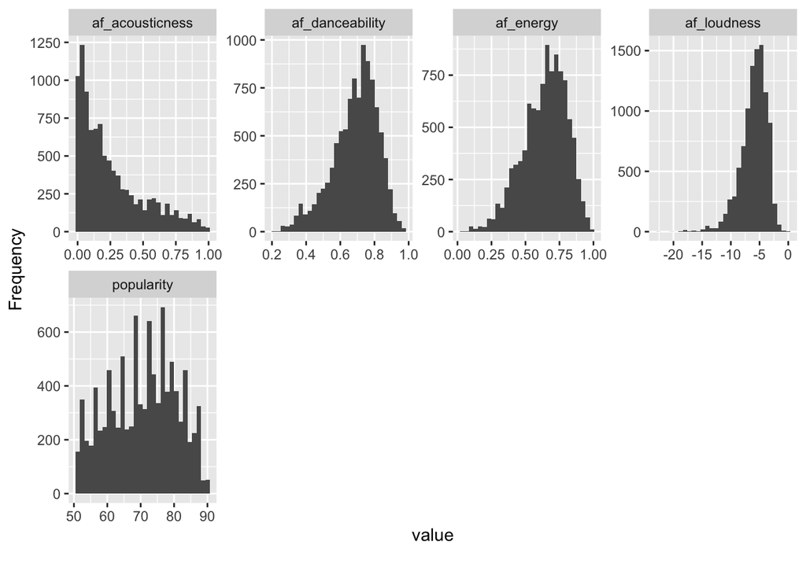

```r
# getting a general idea of variables and their frequencies
plot_histogram(reduced_data)
```

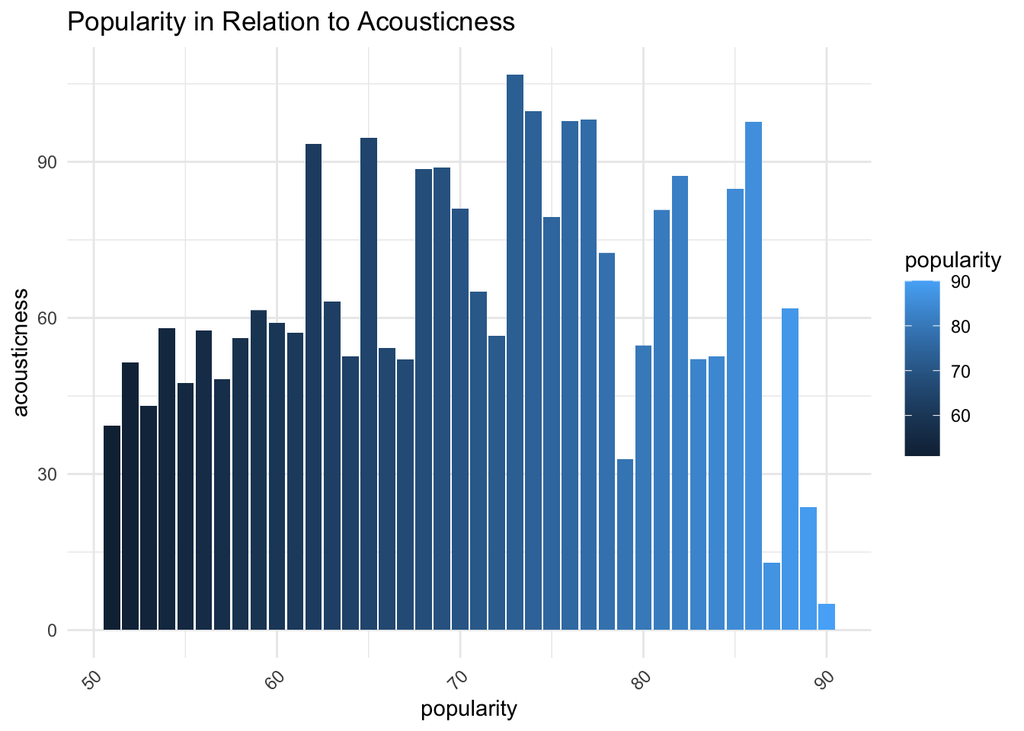

```r
# popularity & acousticness
ggplot(reduced_data, aes(x = popularity, y = af_acousticness, fill = popularity)) +
  geom_bar(stat = "identity") +
  labs(title = "Popularity in Relation to Acousticness", x = "popularity", y = "acousticness") +
  theme_minimal() +
  theme(axis.text.x = element_text(angle = 45, hjust = 1))
```

## **Histograms of relevant variables**

I will now visualize the distributions of my variables of interest (danceability, loudness, acousticness, energy) with histograms. This will help me determine what models would work best for our variables of interest.

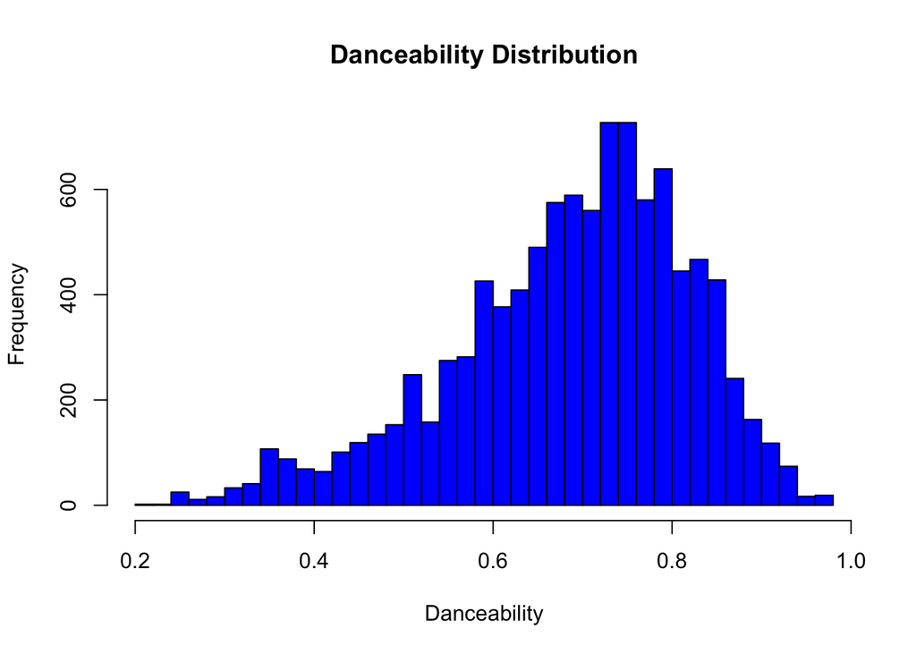

```r
hist(reduced_data$af_danceability, main="Danceability Distribution", xlab="Danceability", col="blue", breaks=30)
```

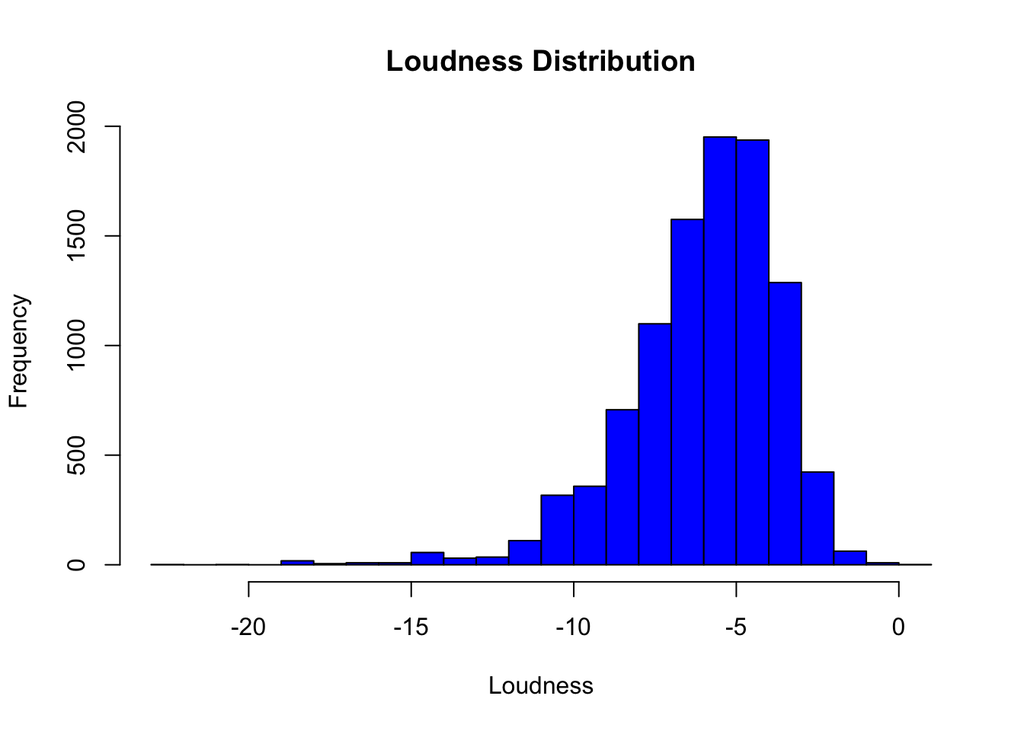

```r
hist(reduced_data$af_loudness, main = 'Loudness Distribution', xlab = 'Loudness', col = 'blue', breaks = 30)
```

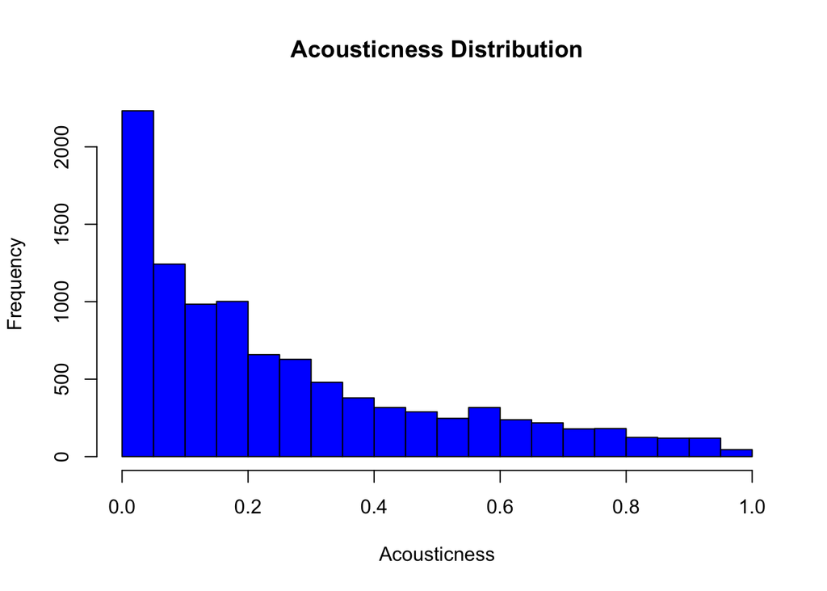

```r
hist(reduced_data$af_acousticness, main = 'Acousticness Distribution', xlab = "Acousticness", col = 'blue', breaks = 30)
```